# Data 607 : Assignment 2 - Tidyverse Create

Ramnivas Singh

02/14/2021

## Overview

Task here is to Create an example. Using one or more TidyVerse packages, and any dataset from fivethirtyeight.com or Kaggle, create a programming sample “vignette” that demonstrates how to use one or more of the capabilities of the selected TidyVerse package with your selected dataset. I picked up ‘COVID-19 World Vaccination Progress’ dataset from [Kaggle](https://www.kaggle.com/gpreda/covid-world-vaccination-progress)

## Summary

The worldwide endeavor to create a safe and effective COVID-19 vaccine is bearing fruit. A handful of vaccines now have been authorized around the globe; many more remain in development.The biggest vaccination campaign in history is underway. More than 172 million doses have been administered across 77 countries, according to data collected by Bloomberg. The latest rate was roughly 5.92 million doses a day. To bring this pandemic to an end, a large share of the world needs to be immune to the virus. in this assignment, Kaggle dataset will be used for analysis to apply Tidyverse capabilities.

## Tidyverse

The tidyverse is a coherent system of packages for data manipulation, exploration and visualization that share a common design philosophy. Tidyverse packages are intended to make statisticians and data scientists more productive by guiding them through workflows that facilitate communication, and result in reproducible work products.

```
Data Wrangling and Transformation
* dplyr
* tidyr
* stringr
* forcats
Data Import and Management
* tibble
* readr
Functional Programming
* purrr
Data Visualization and Exploration
* ggplot2
```

More information on tidyverse can be found [here](https://tidyverse.org)

## Data Collection

Data set from [Kaggle](https://www.kaggle.com/gpreda/covid-world-vaccination-progress) is used for this assignment.

## Load tidyverse packages

```r
library(tidyverse) # Load all "tidyverse" libraries.
```

```r
# OR
# library(readr)   # Read tabular data.
# library(tidyr)   # Data frame tidying functions.
# library(dplyr)   # General data frame manipulation.
# library(ggplot2) # Flexible plotting.
library(viridis)   # Viridis color scale.
```

## Load Vaccination Progress data

```r
#Source: https://www.kaggle.com/gpreda/covid-world-vaccination-progress/download
url='https://raw.githubusercontent.com/rnivas2028/MSDS/Data607/Tidyverse/country_vaccinations.csv'
country_vaccinations <- read.csv(url(url))
```

## Tidyverse capabilities

### glimpse

To look at the variable names and types

```r
glimpse(country_vaccinations)
```

```
## Rows: 3,081
## Columns: 15
## $ country                             <chr> "Albania", "Albania", "Albania", "~
## $ iso_code                            <chr> "ALB", "ALB", "ALB", "ALB", "ALB",~
## $ date                                <chr> "2021-01-10", "2021-01-11", "2021-~
## $ total_vaccinations                  <dbl> 0, NA, 128, 188, 266, 308, 369, 40~
## $ people_vaccinated                   <dbl> 0, NA, 128, 188, 266, 308, 369, 40~
## $ people_fully_vaccinated             <dbl> NA, NA, NA, NA, NA, NA, NA, NA, NA~
## $ daily_vaccinations_raw              <dbl> NA, NA, NA, 60, 78, 42, 61, 36, 42~
## $ daily_vaccinations                  <dbl> NA, 64, 64, 63, 66, 62, 62, 58, 55~
## $ total_vaccinations_per_hundred      <dbl> 0.00, NA, 0.00, 0.01, 0.01, 0.01, ~
## $ people_vaccinated_per_hundred       <dbl> 0.00, NA, 0.00, 0.01, 0.01, 0.01, ~
## $ people_fully_vaccinated_per_hundred <dbl> NA, NA, NA, NA, NA, NA, NA, NA, NA~
## $ daily_vaccinations_per_million      <dbl> NA, 22, 22, 22, 23, 22, 22, 20, 19~
## $ vaccines                            <chr> "Pfizer/BioNTech", "Pfizer/BioNTec~
## $ source_name                         <chr> "Ministry of Health", "Ministry of~
## $ source_website                      <chr> "https://shendetesia.gov.al/vaksin~
```

### summary

To get an overview of data set

```r
summary(country_vaccinations)
```

```
##    country            iso_code             date           total_vaccinations
##  Length:3081        Length:3081        Length:3081        Min.   :       0
##  Class :character   Class :character   Class :character   1st Qu.:   25588
##  Mode  :character   Mode  :character   Mode  :character   Median :  160378
##                                                           Mean   : 1314264
##                                                           3rd Qu.:  673445
##                                                           Max.   :50641884
##                                                           NA's   :1101
##  people_vaccinated  people_fully_vaccinated daily_vaccinations_raw
##  Min.   :       0   Min.   :       1        Min.   :      0
##  1st Qu.:   24773   1st Qu.:    6120        1st Qu.:   1901
##  Median :  142831   Median :   25175        Median :  10672
##  Mean   : 1098716   Mean   :  318684        Mean   :  72091
##  3rd Qu.:  568942   3rd Qu.:  139000        3rd Qu.:  54804
##  Max.   :37056122   Max.   :13082172        Max.   :2231326
##  NA's   :1438       NA's   :2065            NA's   :1439
##  daily_vaccinations total_vaccinations_per_hundred
##  Min.   :      1    Min.   : 0.000
##  1st Qu.:   1218    1st Qu.: 0.480
##  Median :   6124    Median : 1.975
##  Mean   :  55768    Mean   : 5.231
##  3rd Qu.:  28056    3rd Qu.: 4.550
##  Max.   :1916190    Max.   :72.580
##  NA's   :121        NA's   :1101
##  people_vaccinated_per_hundred people_fully_vaccinated_per_hundred
##  Min.   : 0.000                Min.   : 0.0000
##  1st Qu.: 0.500                1st Qu.: 0.0875
##  Median : 2.080                Median : 0.5200
##  Mean   : 4.607                Mean   : 1.4042
##  3rd Qu.: 3.685                3rd Qu.: 1.1425
##  Max.   :46.300                Max.   :28.3900
##  NA's   :1438                  NA's   :2065
##  daily_vaccinations_per_million   vaccines         source_name
##  Min.   :    0.0                Length:3081        Length:3081
##  1st Qu.:  345.8                Class :character   Class :character
##  Median :  952.5                Mode  :character   Mode  :character
##  Mean   : 2129.8
##  3rd Qu.: 1787.2
##  Max.   :30869.0
##  NA's   :121
##  source_website
##  Length:3081
##  Class :character
##  Mode  :character
##
##
##
##
```

### select

To get selected columns from a large data sets with many columns

```r
head(country_vaccinations%>%select(country, total_vaccinations, people_vaccinated,  people_fully_vaccinated),5)
```

```
##   country total_vaccinations people_vaccinated people_fully_vaccinated
## 1 Albania                  0                 0                      NA
## 2 Albania                 NA                NA                      NA
## 3 Albania                128               128                      NA
## 4 Albania                188               188                      NA
## 5 Albania                266               266                      NA
```

### rename

To rename columns in a data set

```r
head(rename(country_vaccinations, 'Total Vaccinations'=total_vaccinations),5)
```

```
##   country iso_code       date Total Vaccinations people_vaccinated
## 1 Albania      ALB 2021-01-10                  0                 0
## 2 Albania      ALB 2021-01-11                 NA                NA
## 3 Albania      ALB 2021-01-12                128               128
## 4 Albania      ALB 2021-01-13                188               188
## 5 Albania      ALB 2021-01-14                266               266
##   people_fully_vaccinated daily_vaccinations_raw daily_vaccinations
## 1                      NA                     NA                 NA
## 2                      NA                     NA                 64
## 3                      NA                     NA                 64
## 4                      NA                     60                 63
## 5                      NA                     78                 66
##   total_vaccinations_per_hundred people_vaccinated_per_hundred
## 1                           0.00                          0.00
## 2                             NA                            NA
```

[output cut: 21 more lines]

### sample_n

To pick random sample from the data set

```r
head(sample_n(country_vaccinations, 5))
```

```
##      country iso_code       date total_vaccinations people_vaccinated
## 1 Bangladesh      BGD 2021-02-10             337769            337769
## 2    Denmark      DNK 2021-01-11             117583            117583
## 3      India      IND 2021-01-18             454049                NA
## 4  Singapore      SGP 2021-01-27             113050            113000
## 5      Chile      CHL 2021-02-06             620640            607454
##   people_fully_vaccinated daily_vaccinations_raw daily_vaccinations
## 1                      NA                 158451              45549
## 2                      NA                    657               8972
## 3                      NA                 229748             151350
## 4                      50                     NA               9116
## 5                   13186                  27348              79048
##   total_vaccinations_per_hundred people_vaccinated_per_hundred
## 1                           0.21                          0.21
## 2                           2.03                          2.03
```

[output cut: 21 more lines]

### group_by

To group data set into smaller data groups

```r
by_country <- group_by(country_vaccinations, country)
summarise <- summarise(by_country, count = n(),
country_vaccinations_mean = mean(total_vaccinations, na.rm = TRUE))
by_country <-head(summarise %>% arrange(desc(country_vaccinations_mean)))
```

### ggplot

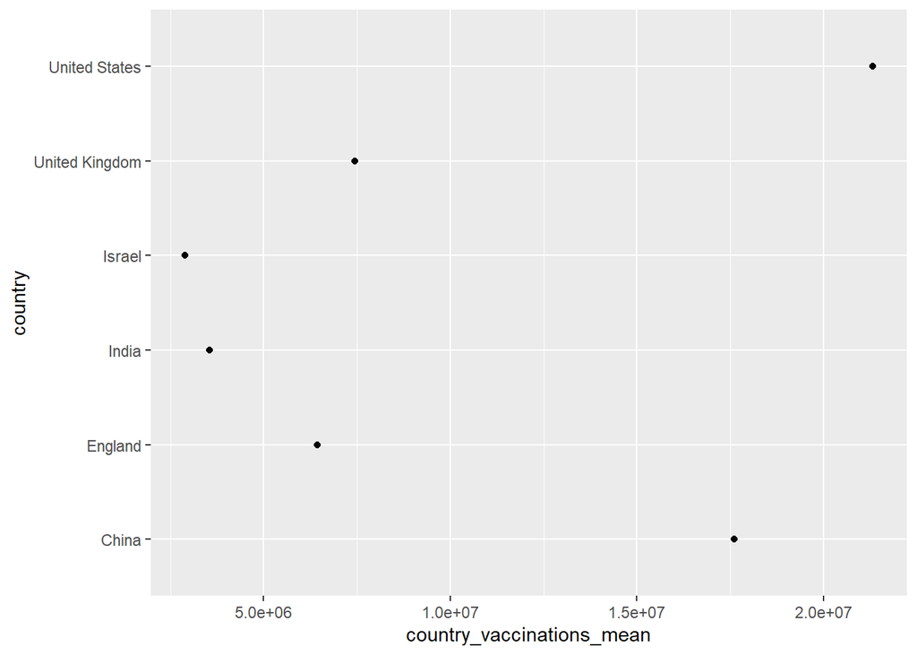

```r
ggplot(by_country, aes(x=country_vaccinations_mean, y=country)) + geom_point()
```

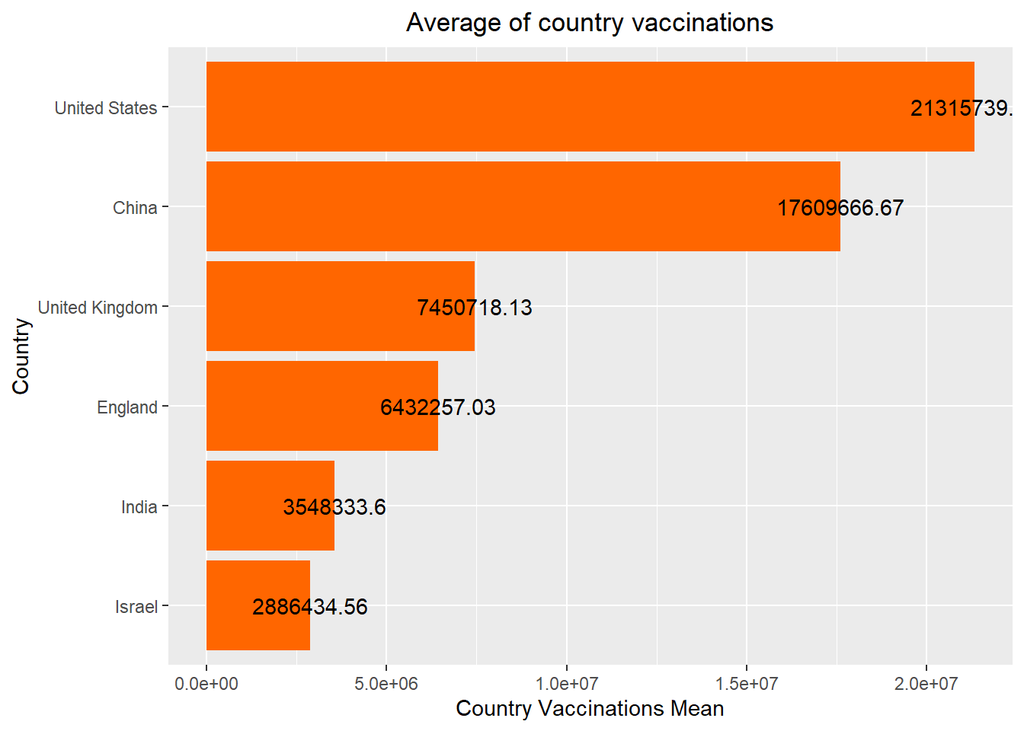

```r
ggplot(data=by_country, aes(x=(reorder(country, country_vaccinations_mean)), y = country_vaccinations_mean))+
  geom_bar(stat="identity", fill="#FF6600")+ coord_flip()+
  labs(title="Average of country vaccinations", x= "Country", y = "Country Vaccinations Mean")+
  geom_text(aes(label=round(country_vaccinations_mean, digits = 2)))+
  theme(plot.title=element_text(hjust=0.5))
```